# Practical machine learning course project

ismail

12/31/2021

## Abstract

In this report of the Practical machine learning course project, we will use data from accelerometers on the belt, forearm, arm, and dumbell of 6 participants to predict the manner in which they did the exercise. This is represented by “classe” variable in the training data set. Since the outcome of the prediction is multiple classes I used 4 classification prediction models: **Decision Tree**, **Random Forest**, **Gradient Boosted Trees**, **Linear Discriminant Analysis** I split the training dataset into 2 parts: 75% to train the models and 25% for testing/validation to evaluate the accuracy of each algorithm then I used 3-folds cross-validation on the training set and choose the more accurate model to predict 20 samples. Random forest prediction model is the most accurate with an accuracy of 99.1% and an Out-of-sample error:0.8%.

## Getting and cleaning data :

The data for this project come from this source: http://web.archive.org/web/20161224072740/http:/groupware.les.inf.puc-rio.br/har. If you use the document you create for this class for any purpose please cite them as they have been very generous in allowing their data to be used for this kind of assignment.

```r
if(!require(ggcorrplot)) install.packages("ggcorrplot")
library(rattle)
library(ggcorrplot)
library(dplyr)
library(caret)
library(ggplot2)

download.file(url ="https://d396qusza40orc.cloudfront.net/predmachlearn/pml-training.csv",destfile = "sport_training.csv")

download.file(url ="https://d396qusza40orc.cloudfront.net/predmachlearn/pml-testing.csv",destfile = "sport_testing.csv")

Rawdf_training<-read.csv("sport_training.csv")
Rawdf_testing<-read.csv("sport_testing.csv")
```

### Checking for missing data

- 67 variables have more than 97% missing data ,i choose to remove them.

```r
sort(sapply(Rawdf_training, function(x){sum(is.na(x)*1)/length(x)}),decreasing = TRUE)[1:70]
```

```
##            max_roll_belt           max_picth_belt            min_roll_belt
##                0.9793089                0.9793089                0.9793089
##           min_pitch_belt      amplitude_roll_belt     amplitude_pitch_belt
##                0.9793089                0.9793089                0.9793089
##     var_total_accel_belt            avg_roll_belt         stddev_roll_belt
##                0.9793089                0.9793089                0.9793089
##            var_roll_belt           avg_pitch_belt        stddev_pitch_belt
##                0.9793089                0.9793089                0.9793089
##           var_pitch_belt             avg_yaw_belt          stddev_yaw_belt
##                0.9793089                0.9793089                0.9793089
##             var_yaw_belt            var_accel_arm             avg_roll_arm
##                0.9793089                0.9793089                0.9793089
##          stddev_roll_arm             var_roll_arm            avg_pitch_arm
##                0.9793089                0.9793089                0.9793089
##         stddev_pitch_arm            var_pitch_arm              avg_yaw_arm
##                0.9793089                0.9793089                0.9793089
##           stddev_yaw_arm              var_yaw_arm             max_roll_arm
##                0.9793089                0.9793089                0.9793089
##            max_picth_arm              max_yaw_arm             min_roll_arm
##                0.9793089                0.9793089                0.9793089
##            min_pitch_arm              min_yaw_arm       amplitude_roll_arm
##                0.9793089                0.9793089                0.9793089
##      amplitude_pitch_arm        amplitude_yaw_arm        max_roll_dumbbell
##                0.9793089                0.9793089                0.9793089
##       max_picth_dumbbell        min_roll_dumbbell       min_pitch_dumbbell
##                0.9793089                0.9793089                0.9793089
##  amplitude_roll_dumbbell amplitude_pitch_dumbbell       var_accel_dumbbell
##                0.9793089                0.9793089                0.9793089
##        avg_roll_dumbbell     stddev_roll_dumbbell        var_roll_dumbbell
##                0.9793089                0.9793089                0.9793089
##       avg_pitch_dumbbell    stddev_pitch_dumbbell       var_pitch_dumbbell
##                0.9793089                0.9793089                0.9793089
##         avg_yaw_dumbbell      stddev_yaw_dumbbell         var_yaw_dumbbell
##                0.9793089                0.9793089                0.9793089
##         max_roll_forearm        max_picth_forearm         min_roll_forearm
##                0.9793089                0.9793089                0.9793089
##        min_pitch_forearm   amplitude_roll_forearm  amplitude_pitch_forearm
##                0.9793089                0.9793089                0.9793089
##        var_accel_forearm         avg_roll_forearm      stddev_roll_forearm
##                0.9793089                0.9793089                0.9793089
##         var_roll_forearm        avg_pitch_forearm     stddev_pitch_forearm
##                0.9793089                0.9793089                0.9793089
##        var_pitch_forearm          avg_yaw_forearm       stddev_yaw_forearm
##                0.9793089                0.9793089                0.9793089
##          var_yaw_forearm                        X                user_name
##                0.9793089                0.0000000                0.0000000
##     raw_timestamp_part_1
##                0.0000000
```

### Picking the right features :

```r
training <- Rawdf_training %>% select(contains("arm")|contains("belt")|contains("dumbell"),classe)

testing <- Rawdf_testing %>% select(contains("arm")|contains("belt")|contains("dumbell"))
training$classe<-as.factor(training$classe)
```

- Throwing out variables with zero variation :

```r
nzv_inxd<-nearZeroVar(training,saveMetrics = TRUE)$nzv
nzv<-names(training)[nzv_inxd]

training<-training%>%select(-nzv)
```

```
## Note: Using an external vector in selections is ambiguous.
## i Use `all_of(nzv)` instead of `nzv` to silence this message.
## i See <https://tidyselect.r-lib.org/reference/faq-external-vector.html>.
```

```r
testing <-testing%>%select(-nzv)
```

- Removing variables with Na’s in them:

```r
Na_vars<-sapply(training, function(x){sum(is.na(x)*1)/length(x)})
Nvs<-names(Na_vars[Na_vars!=0])

training<-training%>%select(-Nvs)
```

```
## Note: Using an external vector in selections is ambiguous.
## i Use `all_of(Nvs)` instead of `Nvs` to silence this message.
## i See <https://tidyselect.r-lib.org/reference/faq-external-vector.html>.
```

```r
testing<-testing%>%select(-Nvs)
```

- Plotting the correlation matrix for the training data : Apparently most of the variables aren’t strongly correlated.

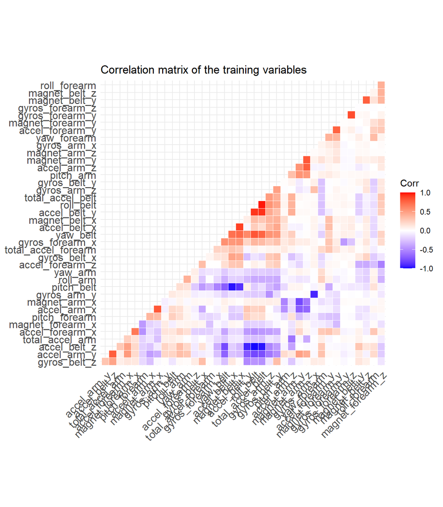

```r
set.seed(12345)
inTrain<-createDataPartition(y=Rawdf_training$classe,p = .75,list = FALSE)
training_subset<-training[inTrain,]
testing_subset<-training[-inTrain,]

control <- trainControl(method="cv", number=3, verboseIter=F)
```

### Random Forests model

Random Forest is a robust machine learning algorithm which performs well on both regression and classification,thus it is suitable for our case.

```r
RF_model_fit<-train(classe~ .,data = training_subset, method="rf", trControl=control, verbose=FALSE)
RF_prdct<-predict(RF_model_fit,newdata=testing_subset)
confusionMatrix(as.factor(testing_subset$classe),RF_prdct)
```

```
## Confusion Matrix and Statistics
##
##           Reference
## Prediction    A    B    C    D    E
##          A 1392    1    0    2    0
##          B    0  944    5    0    0
##          C    1    3  843    8    0
##          D    0    0   12  788    4
##          E    0    1    0    4  896
##
## Overall Statistics
##
##                Accuracy : 0.9916
##                  95% CI : (0.9887, 0.994)
##     No Information Rate : 0.2841
##     P-Value [Acc > NIR] : < 2.2e-16
##
##                   Kappa : 0.9894
##
##  Mcnemar's Test P-Value : NA
##
## Statistics by Class:
##
##                      Class: A Class: B Class: C Class: D Class: E
## Sensitivity            0.9993   0.9947   0.9802   0.9825   0.9956
## Specificity            0.9991   0.9987   0.9970   0.9961   0.9988
## Pos Pred Value         0.9978   0.9947   0.9860   0.9801   0.9945
## Neg Pred Value         0.9997   0.9987   0.9958   0.9966   0.9990
## Prevalence             0.2841   0.1935   0.1754   0.1635   0.1835
## Detection Rate         0.2838   0.1925   0.1719   0.1607   0.1827
## Detection Prevalence   0.2845   0.1935   0.1743   0.1639   0.1837
## Balanced Accuracy      0.9992   0.9967   0.9886   0.9893   0.9972
```

### Generalized Boost Model

Generalized Boosting Models fit many decision trees using boosting method to improve the accuracy of the model.

```r
GBM_Model <- train(classe~ .,data = training_subset, method="gbm", trControl=control, verbose=FALSE)
GBM_prdct<-predict(GBM_Model,newdata=testing_subset)
confusionMatrix(as.factor(testing_subset$classe),GBM_prdct)
```

```
## Confusion Matrix and Statistics
##
##           Reference
## Prediction    A    B    C    D    E
##          A 1368   18    4    4    1
##          B   40  860   43    3    3
##          C    0   61  763   27    4
##          D    2    1   39  749   13
##          E    2   14   10   11  864
##
## Overall Statistics
##
##                Accuracy : 0.9388
##                  95% CI : (0.9318, 0.9454)
##     No Information Rate : 0.2879
##     P-Value [Acc > NIR] : < 2.2e-16
##
##                   Kappa : 0.9226
##
##  Mcnemar's Test P-Value : 0.001035
##
## Statistics by Class:
##
##                      Class: A Class: B Class: C Class: D Class: E
## Sensitivity            0.9688   0.9015   0.8882   0.9433   0.9763
## Specificity            0.9923   0.9775   0.9773   0.9866   0.9908
## Pos Pred Value         0.9806   0.9062   0.8924   0.9316   0.9589
## Neg Pred Value         0.9875   0.9762   0.9763   0.9890   0.9948
## Prevalence             0.2879   0.1945   0.1752   0.1619   0.1805
## Detection Rate         0.2790   0.1754   0.1556   0.1527   0.1762
## Detection Prevalence   0.2845   0.1935   0.1743   0.1639   0.1837
## Balanced Accuracy      0.9806   0.9395   0.9327   0.9650   0.9835
```

### Decision Trees Model

```r
DT_model_fit<-train(classe~ .,data = training_subset, method="rpart", trControl=control)
DT_prdct<-predict(DT_model_fit,newdata=testing_subset)
confusionMatrix(as.factor(testing_subset$classe),DT_prdct)
```

```
## Confusion Matrix and Statistics
##
##           Reference
## Prediction    A    B    C    D    E
##          A 1283    0   89    0   23
##          B  635    0  314    0    0
##          C  457    0  398    0    0
##          D  490    0  314    0    0
##          E  165    0  310    0  426
##
## Overall Statistics
##
##                Accuracy : 0.4296
##                  95% CI : (0.4157, 0.4436)
##     No Information Rate : 0.6179
##     P-Value [Acc > NIR] : 1
##
##                   Kappa : 0.2463
##
##  Mcnemar's Test P-Value : NA
##
## Statistics by Class:
##
##                      Class: A Class: B Class: C Class: D Class: E
## Sensitivity            0.4234       NA  0.27930       NA  0.94878
## Specificity            0.9402   0.8065  0.86864   0.8361  0.89338
## Pos Pred Value         0.9197       NA  0.46550       NA  0.47281
## Neg Pred Value         0.5021       NA  0.74636       NA  0.99425
## Prevalence             0.6179   0.0000  0.29058   0.0000  0.09156
## Detection Rate         0.2616   0.0000  0.08116   0.0000  0.08687
## Detection Prevalence   0.2845   0.1935  0.17435   0.1639  0.18373
## Balanced Accuracy      0.6818       NA  0.57397       NA  0.92108
```

### Linear discriminant analysis

Linear discriminant analysis, normal discriminant analysis, or discriminant function analysis is a generalization of Fisher’s linear discriminant, a method used in statistics and other fields, to find a linear combination of features that characterizes or separates two or more classes of objects or events. source:[wikipedia](https://en.wikipedia.org/wiki/Linear_discriminant_analysis)

```r
lda_model = train(classe~ .,data = training_subset, method="lda",
               trControl = control)
lda_prdct<-predict(lda_model,newdata=testing_subset)
confusionMatrix(testing_subset$classe,lda_prdct)
```

```
## Confusion Matrix and Statistics
##
##           Reference
## Prediction   A   B   C   D   E
##          A 931  66 202 176  20
##          B 113 565 150  74  47
##          C 240 199 303  95  18
##          D  64  40 102 545  53
##          E  63 150  72 118 498
##
## Overall Statistics
##
##                Accuracy : 0.5795
##                  95% CI : (0.5656, 0.5934)
##     No Information Rate : 0.2877
##     P-Value [Acc > NIR] : < 2.2e-16
##
##                   Kappa : 0.4684
##
##  Mcnemar's Test P-Value : < 2.2e-16
##
## Statistics by Class:
##
##                      Class: A Class: B Class: C Class: D Class: E
## Sensitivity            0.6598   0.5539  0.36550   0.5407   0.7830
## Specificity            0.8672   0.9011  0.86454   0.9335   0.9056
## Pos Pred Value         0.6674   0.5954  0.35439   0.6779   0.5527
## Neg Pred Value         0.8632   0.8850  0.87009   0.8871   0.9655
## Prevalence             0.2877   0.2080  0.16905   0.2055   0.1297
## Detection Rate         0.1898   0.1152  0.06179   0.1111   0.1015
## Detection Prevalence   0.2845   0.1935  0.17435   0.1639   0.1837
## Balanced Accuracy      0.7635   0.7275  0.61502   0.7371   0.8443
```

### Choosing the right prediction model

```
##                    Accuracy     Kappa    OS_Error
## Random forest     0.9916395 0.9894257 0.008360522
## Generalized Boost 0.9388254 0.9225844 0.061174551
## Decision Trees    0.4296493 0.2463237 0.570350734
## LDA               0.5795269 0.4683641 0.420473083
```

- **Random forest** prediction model is the most accurate.

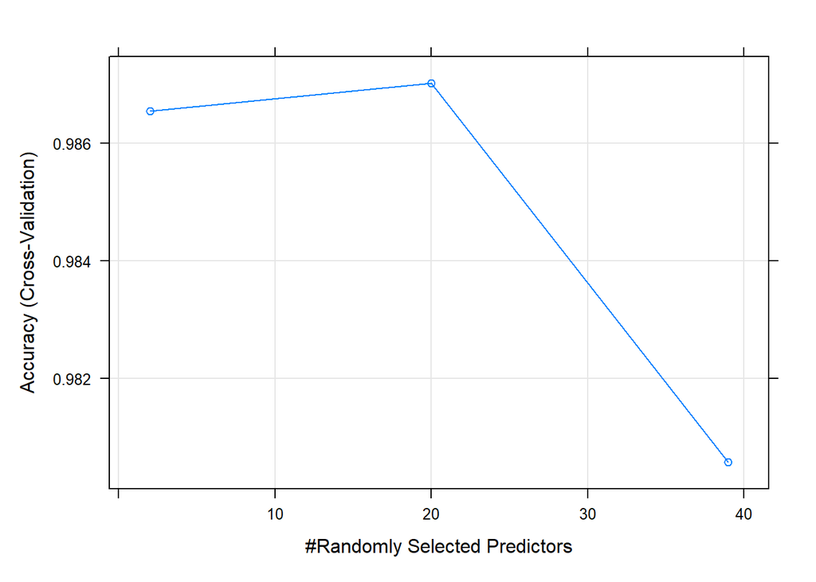

## Prediction on Test dataset

Random forest algorithm performed very well with an accuracy of 99.1% ;we will use it for predicting 20 samples of the test data set:

```r
predict(RF_model_fit,newdata=testing)
```

```
##  [1] B A B A A E D B A A B C B A E E A B B B
## Levels: A B C D E
```